> **Tip**: Welcome to the Investigate a Dataset project! You will find tips in quoted sections like this to help organize your approach to your investigation. Before submitting your project, it will be a good idea to go back through your report and remove these sections to make the presentation of your work as tidy as possible. First things first, you might want to double-click this Markdown cell and change the title so that it reflects your dataset and investigation.

# Project: What could influence birth rate in Kuwait after Gulf War

- Introduction
- Data Wrangling
- Exploratory Data Analysis
- Conclusions

## Introduction

> **Tip**: Birth rate flutruates over the years. This study is looking at the factors that could influence the birth rate between 1991 and 2017 in Kuwait, after Gulf War. After Feb, 1991, Kuwait was liberated. Kuwait spent more than 5 billion to repair oil infrastructure damaged during the Gulf war. In this study, I am particularly interested in how the economy recovery resulting in GDP and female employment rate, thus in turn influenced birth rate.

> The dependent variable is the birth rate. The indepedant variables include female employment rate, GDP, urban population growth, and military expenditure during the same period in Kuwait.

```python
# Use this cell to set up import statements for all of the packages that you
#   plan to use.
import numpy as np
import pandas as pd
import matplotlib.pyplot as plt
%matplotlib inline

# Remember to include a 'magic word' so that your visualizations are plotted
#   inline with the notebook. See this page for more:
#   http://ipython.readthedocs.io/en/stable/interactive/magics.html (later)
```

## Data Wrangling

> **Tip**: In this section of the report, you will load in the data, check for cleanliness, and then trim and clean your dataset for analysis. Make sure that you document your steps carefully and justify your cleaning decisions.

### General Properties

```python
# Load four csv files as mentioned above.

df_birth_rate = pd.read_csv('children_per_woman_total_fertility.csv')
df_employment_rate = pd.read_csv('females_aged_15_24_employment_rate_percent.csv')
df_military_expenditure = pd.read_csv('military_expenditure_percent_of_gdp.csv')
df_urban_growth = pd.read_csv('urban_population_growth_annual_percent.csv')
df_gdp = pd.read_csv('income_per_person_gdppercapita_ppp_inflation_adjusted.csv')
```

```python
# investigate each table
# birth rate
df_birth_rate.shape
```

```
(184, 220)
```

```python
# Female employment rate
df_employment_rate.shape
```

```
(179, 33)
```

```python
# Urban growth rate
df_urban_growth.shape
```

```
(194, 59)
```

```python
# military expenditure
df_military_expenditure.shape
```

```
(165, 59)
```

```python
# gdp
df_gdp.shape
```

```
(193, 220)
```

```python
df_birth_rate.head()
```

|  | country | 1800 | 1801 | 1802 | 1803 | 1804 | 1805 | 1806 | 1807 | 1808 | ... | 2009 | 2010 | 2011 | 2012 | 2013 | 2014 | 2015 | 2016 | 2017 | 2018 |
| --- | --- | --- | --- | --- | --- | --- | --- | --- | --- | --- | --- | --- | --- | --- | --- | --- | --- | --- | --- | --- | --- |
| 0 | Afghanistan | 7.00 | 7.00 | 7.00 | 7.00 | 7.00 | 7.00 | 7.00 | 7.00 | 7.00 | ... | 6.04 | 5.82 | 5.60 | 5.38 | 5.17 | 4.98 | 4.80 | 4.64 | 4.48 | 4.33 |
| 1 | Albania | 4.60 | 4.60 | 4.60 | 4.60 | 4.60 | 4.60 | 4.60 | 4.60 | 4.60 | ... | 1.65 | 1.65 | 1.67 | 1.69 | 1.70 | 1.71 | 1.71 | 1.71 | 1.71 | 1.71 |
| 2 | Algeria | 6.99 | 6.99 | 6.99 | 6.99 | 6.99 | 6.99 | 6.99 | 6.99 | 6.99 | ... | 2.83 | 2.89 | 2.93 | 2.94 | 2.92 | 2.89 | 2.84 | 2.78 | 2.71 | 2.64 |
| 3 | Angola | 6.93 | 6.93 | 6.93 | 6.93 | 6.93 | 6.93 | 6.93 | 6.94 | 6.94 | ... | 6.24 | 6.16 | 6.08 | 6.00 | 5.92 | 5.84 | 5.77 | 5.69 | 5.62 | 5.55 |
| 4 | Antigua and Barbuda | 5.00 | 5.00 | 4.99 | 4.99 | 4.99 | 4.98 | 4.98 | 4.97 | 4.97 | ... | 2.15 | 2.13 | 2.12 | 2.10 | 2.09 | 2.08 | 2.06 | 2.05 | 2.04 | 2.03 |

5 rows × 220 columns

```python
# take data from 1991 to 2017
# birth rate
df_birth_rate = df_birth_rate.filter(items=['country', '1991', '1992', '1993', '1994', '1995', '1996', '1997', '1998', '1999', '2000', '2001', '2002', '2003', '2004', '2005', '2006', '2007', '2008', '2009', '2010', '2011', '2012', '2013', '2014', '2015', '2016','2017'])
df_birth_rate.head(1)
```

|  | country | 1991 | 1992 | 1993 | 1994 | 1995 | 1996 | 1997 | 1998 | 1999 | ... | 2008 | 2009 | 2010 | 2011 | 2012 | 2013 | 2014 | 2015 | 2016 | 2017 |
| --- | --- | --- | --- | --- | --- | --- | --- | --- | --- | --- | --- | --- | --- | --- | --- | --- | --- | --- | --- | --- | --- |
| 0 | Afghanistan | 7.48 | 7.5 | 7.54 | 7.57 | 7.61 | 7.63 | 7.64 | 7.62 | 7.57 | ... | 6.25 | 6.04 | 5.82 | 5.6 | 5.38 | 5.17 | 4.98 | 4.8 | 4.64 | 4.48 |

1 rows × 28 columns

```python
# female employment rate
df_employment_rate = df_employment_rate.filter(items=['country', '1991', '1992', '1993', '1994', '1995', '1996', '1997', '1998', '1999', '2000', '2001', '2002', '2003', '2004', '2005', '2006', '2007', '2008', '2009', '2010', '2011', '2012', '2013', '2014', '2015', '2016','2017'])
df_employment_rate.head()
```

|  | country | 1991 | 1992 | 1993 | 1994 | 1995 | 1996 | 1997 | 1998 | 1999 | ... | 2008 | 2009 | 2010 | 2011 | 2012 | 2013 | 2014 | 2015 | 2016 | 2017 |
| --- | --- | --- | --- | --- | --- | --- | --- | --- | --- | --- | --- | --- | --- | --- | --- | --- | --- | --- | --- | --- | --- |
| 0 | Afghanistan | 12.8 | 13.1 | 12.80 | 12.7 | 12.90 | 12.80 | 12.70 | 12.70 | 12.70 | ... | 13.50 | 13.80 | 13.50 | 13.90 | 14.7 | 15.40 | 16.20 | 17.10 | 17.90 | 18.00 |
| 1 | Albania | 42.5 | 42.3 | 38.00 | 37.5 | 36.40 | 37.00 | 40.30 | 37.20 | 35.20 | ... | 22.90 | 20.60 | 19.30 | 19.90 | 20.6 | 14.90 | 13.80 | 13.30 | 15.70 | 16.40 |
| 2 | Algeria | 10.7 | 10.2 | 9.59 | 9.1 | 7.97 | 8.53 | 8.68 | 7.89 | 7.07 | ... | 5.69 | 5.58 | 5.75 | 6.69 | 6.3 | 6.22 | 5.06 | 4.76 | 5.07 | 5.05 |
| 3 | Angola | 25.4 | 25.7 | 25.70 | 25.1 | 24.20 | 24.30 | 24.60 | 24.70 | 24.80 | ... | 37.30 | 41.00 | 44.30 | 48.00 | 47.9 | 47.80 | 47.70 | 47.60 | 46.60 | 45.90 |
| 4 | Argentina | 33.7 | 32.4 | 26.60 | 25.1 | 17.50 | 20.10 | 21.60 | 25.10 | 24.20 | ... | 27.20 | 25.90 | 23.60 | 24.90 | 24.2 | 23.90 | 23.20 | 22.90 | 22.10 | 21.70 |

5 rows × 28 columns

```python
# urban growth
df_urban_growth = df_urban_growth.filter(items=['country', '1991', '1992', '1993', '1994', '1995', '1996', '1997', '1998', '1999', '2000', '2001', '2002', '2003', '2004', '2005', '2006', '2007', '2008', '2009', '2010', '2011', '2012', '2013', '2014', '2015', '2016','2017'])
df_urban_growth.head()
```

|  | country | 1991 | 1992 | 1993 | 1994 | 1995 | 1996 | 1997 | 1998 | 1999 | ... | 2008 | 2009 | 2010 | 2011 | 2012 | 2013 | 2014 | 2015 | 2016 | 2017 |
| --- | --- | --- | --- | --- | --- | --- | --- | --- | --- | --- | --- | --- | --- | --- | --- | --- | --- | --- | --- | --- | --- |
| 0 | Afghanistan | 7.420 | 8.850 | 9.180 | 8.410 | 7.080 | 5.640 | 4.580 | 4.080 | 4.3100 | ... | 4.020 | 4.090 | 4.350 | 4.64 | 4.83 | 4.89 | 4.76 | 4.53 | 4.28 | 4.090 |
| 1 | Albania | 0.141 | 0.878 | 0.856 | 0.844 | 0.824 | 0.812 | 0.788 | 0.775 | 0.7560 | ... | 1.440 | 1.470 | 1.610 | 1.79 | 1.85 | 1.74 | 1.63 | 1.46 | 1.51 | 1.510 |
| 2 | Algeria | 3.950 | 3.810 | 3.650 | 3.470 | 3.290 | 3.120 | 2.950 | 2.820 | 2.7800 | ... | 2.760 | 2.810 | 2.870 | 2.93 | 2.97 | 2.96 | 2.89 | 2.77 | 2.64 | 2.520 |
| 3 | Andorra | 3.700 | 3.620 | 3.250 | 2.520 | 1.610 | 0.542 | -0.313 | -0.560 | 0.0738 | ... | 0.858 | 0.133 | -0.622 | -1.47 | -2.22 | -2.64 | -2.58 | -2.14 | -1.54 | -0.985 |
| 4 | Angola | 5.560 | 5.700 | 5.720 | 5.620 | 5.430 | 5.220 | 5.070 | 5.020 | 5.1200 | ... | 5.630 | 5.600 | 5.580 | 5.55 | 5.49 | 5.41 | 5.31 | 5.21 | 5.10 | 4.990 |

5 rows × 28 columns

```python
# military expenditure
df_military_expenditure = df_military_expenditure.filter(items=['country', '1991', '1992', '1993', '1994', '1995', '1996', '1997', '1998', '1999', '2000', '2001', '2002', '2003', '2004', '2005', '2006', '2007', '2008', '2009', '2010', '2011', '2012', '2013', '2014', '2015', '2016','2017'])
df_military_expenditure.head()
```

|  | country | 1991 | 1992 | 1993 | 1994 | 1995 | 1996 | 1997 | 1998 | 1999 | ... | 2008 | 2009 | 2010 | 2011 | 2012 | 2013 | 2014 | 2015 | 2016 | 2017 |
| --- | --- | --- | --- | --- | --- | --- | --- | --- | --- | --- | --- | --- | --- | --- | --- | --- | --- | --- | --- | --- | --- |
| 0 | Afghanistan | NaN | NaN | NaN | NaN | NaN | NaN | NaN | NaN | NaN | ... | 2.330 | 2.060 | 1.900 | 1.780 | 1.140 | 1.050 | 1.300 | 0.993 | 0.955 | 0.916 |
| 1 | Albania | 5.79 | 4.45 | 3.20 | 2.50 | 2.10 | 1.38 | 1.28 | 1.24 | 1.25 | ... | 1.980 | 1.520 | 1.560 | 1.530 | 1.490 | 1.410 | 1.350 | 1.160 | 1.100 | 1.250 |
| 2 | Algeria | 1.24 | 2.19 | 2.56 | 3.14 | 2.96 | 3.09 | 3.64 | 3.97 | 3.76 | ... | 3.020 | 3.850 | 3.520 | 4.330 | 4.460 | 4.840 | 5.550 | 6.270 | 6.420 | 5.910 |
| 3 | Angola | 8.12 | 5.25 | 16.10 | 5.22 | 4.28 | 2.45 | 5.97 | 2.62 | 17.30 | ... | 3.760 | 4.390 | 4.240 | 3.500 | 3.640 | 4.880 | 5.400 | 3.520 | 2.960 | 2.470 |
| 4 | Argentina | 1.51 | 1.42 | 1.42 | 1.46 | 1.47 | 1.24 | 1.14 | 1.14 | 1.22 | ... | 0.763 | 0.887 | 0.815 | 0.764 | 0.785 | 0.838 | 0.878 | 0.850 | 0.813 | 0.891 |

5 rows × 28 columns

```python
# gdp
df_gdp = df_gdp.filter(items=['country', '1991', '1992', '1993', '1994', '1995', '1996', '1997', '1998', '1999', '2000', '2001', '2002', '2003', '2004', '2005', '2006', '2007', '2008', '2009', '2010', '2011', '2012', '2013', '2014', '2015', '2016','2017'])
df_gdp.head()
```

|  | country | 1991 | 1992 | 1993 | 1994 | 1995 | 1996 | 1997 | 1998 | 1999 | ... | 2008 | 2009 | 2010 | 2011 | 2012 | 2013 | 2014 | 2015 | 2016 | 2017 |
| --- | --- | --- | --- | --- | --- | --- | --- | --- | --- | --- | --- | --- | --- | --- | --- | --- | --- | --- | --- | --- | --- |
| 0 | Afghanistan | 1030 | 950 | 818 | 732 | 881 | 904 | 930 | 956 | 982 | ... | 1300 | 1530 | 1610 | 1660 | 1840 | 1810 | 1780 | 1750 | 1740 | 1800 |
| 1 | Albania | 3230 | 3010 | 3320 | 3620 | 4130 | 4530 | 4070 | 4460 | 5100 | ... | 9150 | 9530 | 9930 | 10200 | 10400 | 10500 | 10700 | 11000 | 11400 | 11900 |
| 2 | Algeria | 9870 | 9820 | 9400 | 9130 | 9300 | 9510 | 9460 | 9800 | 9970 | ... | 12700 | 12600 | 12900 | 13000 | 13200 | 13300 | 13500 | 13700 | 14000 | 13800 |
| 3 | Andorra | 28000 | 27200 | 26000 | 25900 | 26100 | 27200 | 29700 | 30800 | 31900 | ... | 41400 | 41700 | 39000 | 42000 | 41900 | 43700 | 44900 | 46600 | 48200 | 49800 |
| 4 | Angola | 4210 | 3790 | 2760 | 2770 | 2970 | 3210 | 3370 | 3500 | 3510 | ... | 5980 | 5910 | 5900 | 5910 | 6000 | 6190 | 6260 | 6230 | 6030 | 5940 |

5 rows × 28 columns

```python
# get data for Kuwait
# birth rate
df_birth_rate_kuwait = df_birth_rate[df_birth_rate['country'] == "Kuwait"]
df_birth_rate_kuwait.head()
```

|  | country | 1991 | 1992 | 1993 | 1994 | 1995 | 1996 | 1997 | 1998 | 1999 | ... | 2008 | 2009 | 2010 | 2011 | 2012 | 2013 | 2014 | 2015 | 2016 | 2017 |
| --- | --- | --- | --- | --- | --- | --- | --- | --- | --- | --- | --- | --- | --- | --- | --- | --- | --- | --- | --- | --- | --- |
| 86 | Kuwait | 2.79 | 2.68 | 2.64 | 2.66 | 2.72 | 2.8 | 2.86 | 2.9 | 2.89 | ... | 2.34 | 2.28 | 2.22 | 2.15 | 2.09 | 2.05 | 2.01 | 1.99 | 1.97 | 1.96 |

1 rows × 28 columns

```python
# female employment rate
df_employment_rate_kuwait = df_employment_rate[df_employment_rate['country'] == "Kuwait"]
df_employment_rate_kuwait.head()
```

|  | country | 1991 | 1992 | 1993 | 1994 | 1995 | 1996 | 1997 | 1998 | 1999 | ... | 2008 | 2009 | 2010 | 2011 | 2012 | 2013 | 2014 | 2015 | 2016 | 2017 |
| --- | --- | --- | --- | --- | --- | --- | --- | --- | --- | --- | --- | --- | --- | --- | --- | --- | --- | --- | --- | --- | --- |
| 83 | Kuwait | 18.4 | 18.7 | 19.0 | 19.5 | 19.2 | 20.2 | 19.8 | 19.8 | 20.0 | ... | 22.1 | 22.9 | 23.6 | 20.3 | 17.8 | 17.0 | 16.8 | 15.7 | 15.6 | 16.6 |

1 rows × 28 columns

```python
# urban growth
df_urban_growth_kuwait = df_urban_growth[df_urban_growth['country'] == "Kuwait"]
df_urban_growth_kuwait.head()
```

|  | country | 1991 | 1992 | 1993 | 1994 | 1995 | 1996 | 1997 | 1998 | 1999 | ... | 2008 | 2009 | 2010 | 2011 | 2012 | 2013 | 2014 | 2015 | 2016 | 2017 |
| --- | --- | --- | --- | --- | --- | --- | --- | --- | --- | --- | --- | --- | --- | --- | --- | --- | --- | --- | --- | --- | --- |
| 88 | Kuwait | -3.08 | NaN | NaN | NaN | NaN | 1.32 | 5.01 | 6.83 | 6.38 | ... | 5.79 | 6.11 | 6.18 | 6.25 | 6.23 | 5.82 | 5.0 | 3.99 | 2.94 | 2.07 |

1 rows × 28 columns

```python
# military expenditure
df_military_expenditure_kuwait = df_military_expenditure[df_military_expenditure['country'] == "Kuwait"]
df_military_expenditure_kuwait.head()
```

|  | country | 1991 | 1992 | 1993 | 1994 | 1995 | 1996 | 1997 | 1998 | 1999 | ... | 2008 | 2009 | 2010 | 2011 | 2012 | 2013 | 2014 | 2015 | 2016 | 2017 |
| --- | --- | --- | --- | --- | --- | --- | --- | --- | --- | --- | --- | --- | --- | --- | --- | --- | --- | --- | --- | --- | --- |
| 79 | Kuwait | 117.0 | 31.8 | 12.4 | 13.3 | 13.6 | 10.3 | 8.09 | 8.8 | 7.59 | ... | 3.01 | 3.97 | 3.76 | 3.5 | 3.41 | 3.27 | 3.59 | 5.01 | 5.81 | 5.69 |

1 rows × 28 columns

```python
# gdp
df_gdp_kuwait = df_gdp[df_gdp['country'] == "Kuwait"]
df_gdp_kuwait.head()
```

|  | country | 1991 | 1992 | 1993 | 1994 | 1995 | 1996 | 1997 | 1998 | 1999 | ... | 2008 | 2009 | 2010 | 2011 | 2012 | 2013 | 2014 | 2015 | 2016 | 2017 |
| --- | --- | --- | --- | --- | --- | --- | --- | --- | --- | --- | --- | --- | --- | --- | --- | --- | --- | --- | --- | --- | --- |
| 88 | Kuwait | 18500 | 50200 | 68600 | 74400 | 81000 | 80500 | 78400 | 75900 | 70000 | ... | 93700 | 81900 | 75200 | 77500 | 77600 | 74100 | 70800 | 69300 | 67300 | 67700 |

1 rows × 28 columns

```python
# I want to create a table. Year is the index. Columns are birth rate, employment rate, GDP, urban growth and military expenditure.
# First, make a new table having two columns, year and birth rate.
inp = [{'year':'1991', 'birth_rate':2.79}]
df_temp = pd.DataFrame(inp)
df_temp.head()

bf_columns = df_birth_rate_kuwait.columns.values.tolist()
for j in range(1, df_birth_rate_kuwait.shape[1]):
    inp = [{'year': bf_columns[j], 'birth_rate': df_birth_rate_kuwait.iloc[0][j]}]
    df_temp = df_temp.append(pd.DataFrame(inp).round(2))

# check how the new table looks like
df_temp.head()
```

|  | birth_rate | year |
| --- | --- | --- |
| 0 | 2.79 | 1991 |
| 0 | 2.79 | 1991 |
| 0 | 2.68 | 1992 |
| 0 | 2.64 | 1993 |
| 0 | 2.66 | 1994 |

```python
# drop the first row, same as the second row
df_temp.drop_duplicates(inplace=True)
df_temp.head()
```

|  | birth_rate | year |
| --- | --- | --- |
| 0 | 2.79 | 1991 |
| 0 | 2.68 | 1992 |
| 0 | 2.64 | 1993 |
| 0 | 2.66 | 1994 |
| 0 | 2.72 | 1995 |

```python
df_temp.shape
```

```
(27, 2)
```

```python
df_birth_rate_kuwait = df_temp
```

```python
# Do the same for female employment rate
inp = [{'year':'1991', 'employment_rate':18.4}]
df_temp = pd.DataFrame(inp)
df_temp.head()


bf_columns = df_employment_rate_kuwait.columns.values.tolist()
for j in range(1, df_employment_rate_kuwait.shape[1]):
    inp = [{'year': bf_columns[j], 'employment_rate': df_employment_rate_kuwait.iloc[0][j]}]
    df_temp = df_temp.append(pd.DataFrame(inp).round(2))

df_temp.drop_duplicates(inplace=True)
df_employment_rate_kuwait = df_temp
df_employment_rate_kuwait.head()
```

|  | employment_rate | year |
| --- | --- | --- |
| 0 | 18.4 | 1991 |
| 0 | 18.7 | 1992 |
| 0 | 19.0 | 1993 |
| 0 | 19.5 | 1994 |
| 0 | 19.2 | 1995 |

```python
# Repeat for urban growth
inp = [{'year':'1991', 'urban_growth':-3.08}]
df_temp = pd.DataFrame(inp)

bf_columns = df_urban_growth_kuwait.columns.values.tolist()
for j in range(1, df_urban_growth_kuwait.shape[1]):
    inp = [{'year': bf_columns[j], 'urban_growth': df_urban_growth_kuwait.iloc[0][j]}]
    df_temp = df_temp.append(pd.DataFrame(inp).round(3))

df_temp.drop_duplicates(inplace=True)
df_urban_growth_kuwait = df_temp
df_urban_growth_kuwait.head()
```

|  | urban_growth | year |
| --- | --- | --- |
| 0 | -3.08 | 1991 |
| 0 | NaN | 1992 |
| 0 | NaN | 1993 |
| 0 | NaN | 1994 |
| 0 | NaN | 1995 |

```python
# Repeat for military expenditure
inp = [{'year':'1991', 'military_expenditure':117.0}]
df_temp = pd.DataFrame(inp)

bf_columns = df_military_expenditure_kuwait.columns.values.tolist()
for j in range(1, df_military_expenditure_kuwait.shape[1]):
    inp = [{'year': bf_columns[j], 'military_expenditure': df_military_expenditure_kuwait.iloc[0][j]}]
    df_temp = df_temp.append(pd.DataFrame(inp).round(2))

df_temp.drop_duplicates(inplace=True)
df_military_expenditure_kuwait = df_temp
df_military_expenditure_kuwait.head()
```

|  | military_expenditure | year |
| --- | --- | --- |
| 0 | 117.0 | 1991 |
| 0 | 31.8 | 1992 |
| 0 | 12.4 | 1993 |
| 0 | 13.3 | 1994 |
| 0 | 13.6 | 1995 |

```python
# Repeat for gdp
inp = [{'year':'1991', 'gdp':18500}]
df_temp = pd.DataFrame(inp)

bf_columns = df_gdp_kuwait.columns.values.tolist()
for j in range(1, df_gdp_kuwait.shape[1]):
    inp = [{'year': bf_columns[j], 'gdp': df_gdp_kuwait.iloc[0][j]}]
    df_temp = df_temp.append(pd.DataFrame(inp).round(1))

df_temp.drop_duplicates(inplace=True)
df_gdp_kuwait = df_temp
df_gdp_kuwait.head()
```

|  | gdp | year |
| --- | --- | --- |
| 0 | 18500 | 1991 |
| 0 | 50200 | 1992 |
| 0 | 68600 | 1993 |
| 0 | 74400 | 1994 |
| 0 | 81000 | 1995 |

> **Tip**: You should *not* perform too many operations in each cell. Create cells freely to explore your data. One option that you can take with this project is to do a lot of explorations in an initial notebook. These don't have to be organized, but make sure you use enough comments to understand the purpose of each code cell. Then, after you're done with your analysis, create a duplicate notebook where you will trim the excess and organize your steps so that you have a flowing, cohesive report.

> **Tip**: Make sure that you keep your reader informed on the steps that you are taking in your investigation. Follow every code cell, or every set of related code cells, with a markdown cell to describe to the reader what was found in the preceding cell(s). Try to make it so that the reader can then understand what they will be seeing in the following cell(s).

### Data Cleaning (Replace this with more specific notes!)

```python
# Merge all the tables.
df_merge = pd.merge(df_birth_rate_kuwait, df_employment_rate_kuwait, on = 'year')
df_merge = pd.merge(df_merge, df_urban_growth_kuwait, on = 'year')
df_merge = pd.merge(df_merge, df_military_expenditure_kuwait, on = 'year')
df_merge = pd.merge(df_merge, df_gdp_kuwait, on = 'year')
df_merge.head()
```

|  | birth_rate | year | employment_rate | urban_growth | military_expenditure | gdp |
| --- | --- | --- | --- | --- | --- | --- |
| 0 | 2.79 | 1991 | 18.4 | -3.08 | 117.0 | 18500 |
| 1 | 2.68 | 1992 | 18.7 | NaN | 31.8 | 50200 |
| 2 | 2.64 | 1993 | 19.0 | NaN | 12.4 | 68600 |
| 3 | 2.66 | 1994 | 19.5 | NaN | 13.3 | 74400 |
| 4 | 2.72 | 1995 | 19.2 | NaN | 13.6 | 81000 |

```python
# investigate the table
df_merge.info()
```

```
<class 'pandas.core.frame.DataFrame'>
Int64Index: 27 entries, 0 to 26
Data columns (total 6 columns):
birth_rate              27 non-null float64
year                    27 non-null object
employment_rate         27 non-null float64
urban_growth            23 non-null float64
military_expenditure    27 non-null float64
gdp                     27 non-null int64
dtypes: float64(4), int64(1), object(1)
memory usage: 1.5+ KB
```

```python
# urban growth is missing four values. I am filling it with the mean value of the average urban growth
df_merge.fillna(df_urban_growth_kuwait.mean().round(2), inplace = True)
df_merge.info()
```

```
<class 'pandas.core.frame.DataFrame'>
Int64Index: 27 entries, 0 to 26
Data columns (total 6 columns):
birth_rate              27 non-null float64
year                    27 non-null object
employment_rate         27 non-null float64
urban_growth            27 non-null float64
military_expenditure    27 non-null float64
gdp                     27 non-null int64
dtypes: float64(4), int64(1), object(1)
memory usage: 1.5+ KB
```

```python
# all cells have value, df_merge table is clean
df_merge.head()
```

|  | birth_rate | year | employment_rate | urban_growth | military_expenditure | gdp |
| --- | --- | --- | --- | --- | --- | --- |
| 0 | 2.79 | 1991 | 18.4 | -3.08 | 117.0 | 18500 |
| 1 | 2.68 | 1992 | 18.7 | 3.98 | 31.8 | 50200 |
| 2 | 2.64 | 1993 | 19.0 | 3.98 | 12.4 | 68600 |
| 3 | 2.66 | 1994 | 19.5 | 3.98 | 13.3 | 74400 |
| 4 | 2.72 | 1995 | 19.2 | 3.98 | 13.6 | 81000 |

## Exploratory Data Analysis

> **Tip**: Now that you've trimmed and cleaned your data, you're ready to move on to exploration. Compute statistics and create visualizations with the goal of addressing the research questions that you posed in the Introduction section. It is recommended that you be systematic with your approach. Look at one variable at a time, and then follow it up by looking at relationships between variables.

### What is Kuwait birth rate associating?

```python
# Let's look at the overall stat first
df_merge.describe()
```

|  | birth_rate | employment_rate | urban_growth | military_expenditure | gdp |
| --- | --- | --- | --- | --- | --- |
| count | 27.000000 | 27.000000 | 27.000000 | 27.000000 | 27.000000 |
| mean | 2.475185 | 19.977778 | 3.981852 | 11.480000 | 74633.333333 |
| std | 0.322507 | 2.386232 | 2.202907 | 21.862846 | 15295.046961 |
| min | 1.960000 | 15.600000 | -3.080000 | 3.010000 | 18500.000000 |
| 25% | 2.185000 | 18.550000 | 2.885000 | 3.675000 | 69350.000000 |
| 50% | 2.550000 | 20.000000 | 3.990000 | 5.810000 | 75200.000000 |
| 75% | 2.745000 | 22.000000 | 5.805000 | 8.445000 | 80750.000000 |
| max | 2.900000 | 23.800000 | 6.830000 | 117.000000 | 96900.000000 |

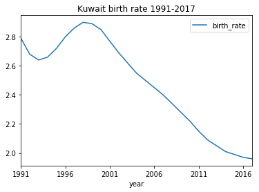

```python
# Kuwait's birth rate from 1991 to 2017.

df_birth_rate_kuwait.plot.line(x= 'year', y='birth_rate', title="Kuwait birth rate 1991-2017");
```

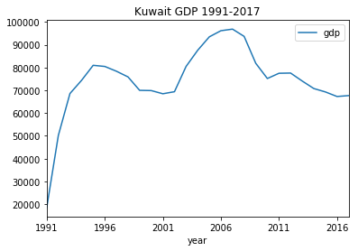

```python
# Kuwait's GDP from 1991 to 2017.

df_gdp_kuwait.plot.line(x= 'year', y='gdp', title="Kuwait GDP 1991-2017");
```

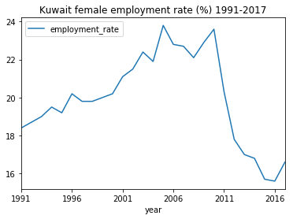

```python
# Kuwait's Female employment rate from 1991 to 2017.

df_employment_rate_kuwait.plot.line(x= 'year', y='employment_rate', title="Kuwait female employment rate (%) 1991-2017");
```

```python
df_employment_rate_kuwait
```

|  | employment_rate | year |
| --- | --- | --- |
| 0 | 18.4 | 1991 |
| 0 | 18.7 | 1992 |
| 0 | 19.0 | 1993 |
| 0 | 19.5 | 1994 |
| 0 | 19.2 | 1995 |
| 0 | 20.2 | 1996 |
| 0 | 19.8 | 1997 |
| 0 | 19.8 | 1998 |
| 0 | 20.0 | 1999 |
| 0 | 20.2 | 2000 |
| 0 | 21.1 | 2001 |
| 0 | 21.5 | 2002 |
| 0 | 22.4 | 2003 |
| 0 | 21.9 | 2004 |
| 0 | 23.8 | 2005 |
| 0 | 22.8 | 2006 |
| 0 | 22.7 | 2007 |
| 0 | 22.1 | 2008 |
| 0 | 22.9 | 2009 |
| 0 | 23.6 | 2010 |
| 0 | 20.3 | 2011 |
| 0 | 17.8 | 2012 |
| 0 | 17.0 | 2013 |
| 0 | 16.8 | 2014 |
| 0 | 15.7 | 2015 |
| 0 | 15.6 | 2016 |
| 0 | 16.6 | 2017 |

#### Observation: the overall birth rate in Kuwait is decreasing. However, from 1993 to 1998, there was a slight increase.

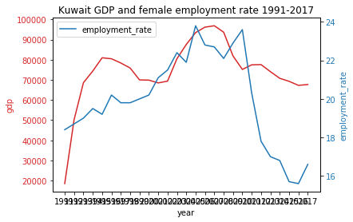

```python
# I want to see if the employment rate is associated with GDP
df_merge_er_gdp = pd.merge(df_employment_rate_kuwait, df_gdp_kuwait, on = 'year')

fig, ax1 = plt.subplots()

color = 'tab:red'
ax1.set_xlabel('year')
ax1.set_ylabel('gdp', color=color)
ax1.plot(df_merge_er_gdp['year'], df_merge_er_gdp['gdp'], color=color)
ax1.tick_params(axis='y', labelcolor=color)
ax2 = ax1.twinx()  # instantiate a second axes that shares the same x-axis

color = 'tab:blue'
ax2.set_ylabel('employment_rate', color=color)  # we already handled the x-label with ax1
ax2.plot(df_merge_er_gdp['year'], df_merge_er_gdp['employment_rate'], color=color)
ax2.tick_params(axis='y', labelcolor=color)

plt.title("Kuwait GDP and female employment rate 1991-2017")   # add a title
plt.legend()
plt.show()
```

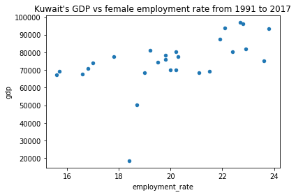

```python
# Plot a scatter gram
df_merge.plot(kind = 'scatter', x = 'employment_rate', y='gdp', title="Kuwait's GDP vs female employment rate from 1991 to 2017");
```

#### Observation: GDP and female employment rate have positive corelation. More women are employed when GDP is higher.

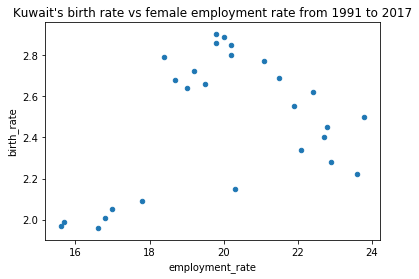

```python
# Now let's see if Kuwait's birth rate and female employment rate are related.
#
df_merge.plot(kind = 'scatter', x = 'employment_rate', y='birth_rate', title="Kuwait's birth rate vs female employment rate from 1991 to 2017");
```

#### Observation: when the female employment rate is less than 20%, birth rate has positive corelation with employment rate. When the employment rate is greater than 20%, birth rate has negative corelation with employment rate.

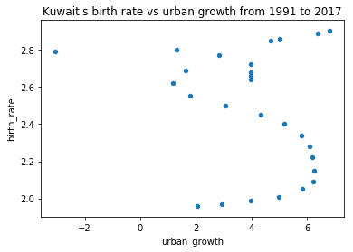

```python
# Kuwait's birth rate vs urban growth from 1991-2017.
#
df_merge.plot(kind = 'scatter', x = 'urban_growth', y='birth_rate', title="Kuwait's birth rate vs urban growth from 1991 to 2017");
```

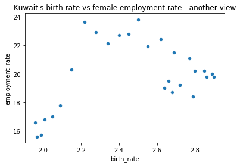

```python
df_merge.plot(kind = 'scatter', x='birth_rate', y = 'employment_rate', title="Kuwait's birth rate vs female employment rate - another view");
```

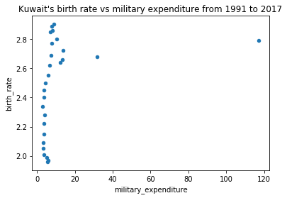

```python
# Kuwait's birth rate vs military expenditure from 1991 to 2017.
#
df_merge.plot(kind = 'scatter', x = 'military_expenditure', y='birth_rate', title="Kuwait's birth rate vs military expenditure from 1991 to 2017");
```

#### Observation: military expenditure is stable most of the time. It has no influence on birth rate.

### Is birth rate relating to GDP?

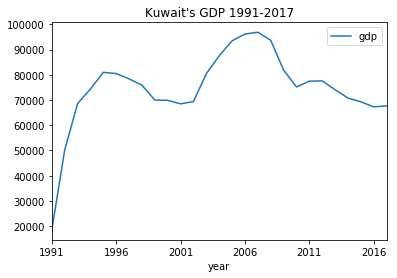

```python
# Plot Kuwait GDP
df_gdp_kuwait.plot.line(x= 'year', y='gdp', title="Kuwait's GDP 1991-2017");# Continue to explore the data to address your additional research
```

#### Observation: After Feb, 1991, Kuwait was liberated. Kuwait spent more than 5 billion to repair oil infrastructure damaged during the Gulf war. The economy recovered quickly.

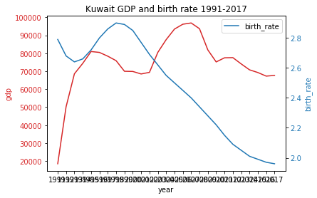

```python
# next I would like to make a plot with both GDP and birth rate to observe if they are related

# Make a table just has birth rate and gdp
df_merge_br_gdp = pd.merge(df_birth_rate_kuwait, df_gdp_kuwait, on = 'year')
df_merge_br_gdp.head()

fig, ax1 = plt.subplots()

color = 'tab:red'
ax1.set_xlabel('year')
ax1.set_ylabel('gdp', color=color)
ax1.plot(df_merge_br_gdp['year'], df_merge_br_gdp['gdp'], color=color)
ax1.tick_params(axis='y', labelcolor=color)
ax2 = ax1.twinx()  # instantiate a second axes that shares the same x-axis

color = 'tab:blue'
ax2.set_ylabel('birth_rate', color=color)  # we already handled the x-label with ax1
ax2.plot(df_merge_br_gdp['year'], df_merge_br_gdp['birth_rate'], color=color)
ax2.tick_params(axis='y', labelcolor=color)

plt.title("Kuwait GDP and birth rate 1991-2017")   # add a title
plt.legend()
plt.show()
```

## Conclusions

> The change of birth rate results from multiple factors. From the many factors, I chose four factors to observe if they have any impact on birth rate. The result shows birth rate is associated with female employment rate, which is tied with GDP. There is no obvious corelation between birth rate and urban growth. Nor does it relate to military expenditure. GDP itself plays very little in determining birth rate. After 1998, birth rate has decreases drastically regardless the flutruation of GDP.

## Limitations

> I filled the null value in urban growth with the mean value. There should be a better value other than the mean value.

## Submitting your Project

> Before you submit your project, you need to create a .html or .pdf version of this notebook in the workspace here. To do that, run the code cell below. If it worked correctly, you should get a return code of 0, and you should see the generated .html file in the workspace directory (click on the orange Jupyter icon in the upper left).

> Alternatively, you can download this report as .html via the **File** > **Download as** submenu, and then manually upload it into the workspace directory by clicking on the orange Jupyter icon in the upper left, then using the Upload button.

> Once you've done this, you can submit your project by clicking on the "Submit Project" button in the lower right here. This will create and submit a zip file with this .ipynb doc and the .html or .pdf version you created. Congratulations!

```python
from subprocess import call
call(['python', '-m', 'nbconvert', 'Investigate_a_Dataset.ipynb'])
```

```
0
```